# Introduction to Probability - Chapter 5 Continous Random Variables

A continous r.v. has a differentiable cdf and the derivative is called the probability density function (pdf). Here, the probability is represented as area under the curve. Hence the probability of X falling in some range is equal to the integral of pmf on this range.

Some interesting formulars.

- $E(X) = \int_{-\infty}^{\infty}xf(x)dx$
- $E(g(X)) = \int_{-\infty}^{\infty}g(x)f(x)dx$

There are three important continous distributions: Uniform, Normal, and Exponential, and Poisson process.

An Unif(a,b) is a r.v. is a random number between a and b. The probability of its falling in to $[c,d] \subset [a,b]$ is proportional to the length of $[c,d]$.

A $\mathcal{N}(\mu,\sigma^2)$ r.v. has a symmetric bell curved PDF centered at $\mu$ with $\sigma$ controls how spreads out the curve is

An $Expo(\lambda)$ r.v. represents the waiting time for the first success in continuous time. This is similar to a Geometric r.v.

A Poisson process is a sequence of arrivals in continous time such that the number of arrivals in an interval of fixed length follows a Poisson distribution.

### Uniform distribution

The pdf of uniform distribution of r.v. X on an interval $[a,b]$ is defined as follows.

$$f(x) = \begin{cases}
\frac{1}{b-a}& \text{ if a < x < b,}\\
0 &\text{ otherwise}
\end{cases}$$
We again have three functions `dunif, punif, runif`.

```r
# pdf function
dunif(3,3,6) # 0.3333
```

```
[1] 0.3333333
```

```r
# cdf function
punif(5,3,6)
```

```
[1] 0.6666667
```

```r
# generate 4 random uniform variables
runif(4,3,6)
```

```
[1] 3.478427 4.192085 4.638642 4.000451
```

### Plots in R

We can use `curve` to plot a function

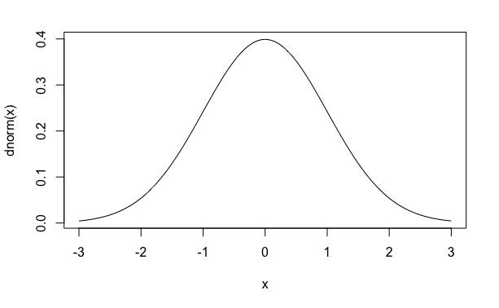

```r
#mysquare = function(x) {
#  x^2;
#}
#curve(mysquare, from=-3, to=3, n=1000)
curve(dnorm, from=-3, to=3, n=1000)
```

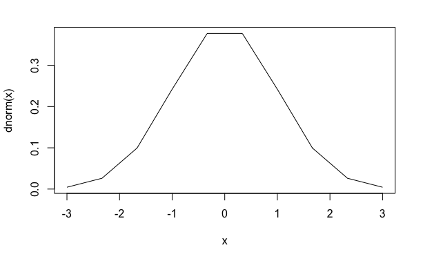

```r
curve(dnorm, from=-3, to=3, n=10)
```

Another function is `plot`.

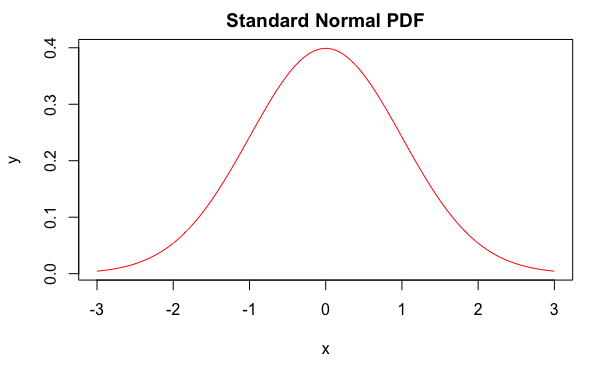

```r
x = seq(-3,3,0.01)
y = dnorm(x)
plot(x,y,type = "l", main = "Standard Normal PDF", col = 'red') # "l" stands for line plot. The default is scatter plot
```

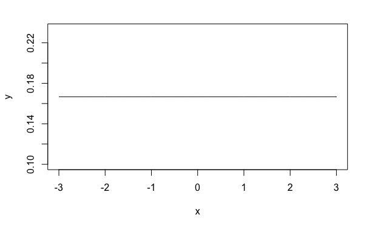

```r
y = dunif(x,-3,3)
plot(x,y, type = "l")
```

### Universality with Logistic